# Мини-проект анализ выживаемости

```r
mod_2 <- survfit(surv_object_1 ~ resid.ds, data = d)
summary(mod_2)
```

```
## Call: survfit(formula = surv_object_1 ~ resid.ds, data = d)
##
##                 resid.ds=1
##  time n.risk n.event survival std.err lower 95% CI upper 95% CI
##   353     11       1    0.909  0.0867        0.754        1.000
##   448      9       1    0.808  0.1225        0.600        1.000
##   563      8       1    0.707  0.1429        0.476        1.000
##   638      7       1    0.606  0.1541        0.368        0.998
##   855      4       1    0.455  0.1749        0.214        0.966
##  1227      1       1    0.000     NaN           NA           NA
##
##                 resid.ds=2
##  time n.risk n.event survival std.err lower 95% CI upper 95% CI
##   156     13       1    0.923  0.0739       0.7890        1.000
##   268     12       1    0.846  0.1001       0.6711        1.000
##   464      7       1    0.725  0.1410       0.4955        1.000
##   475      6       1    0.604  0.1612       0.3583        1.000
##   769      4       1    0.453  0.1782       0.2098        0.979
##  1040      2       1    0.227  0.1834       0.0464        1.000
```

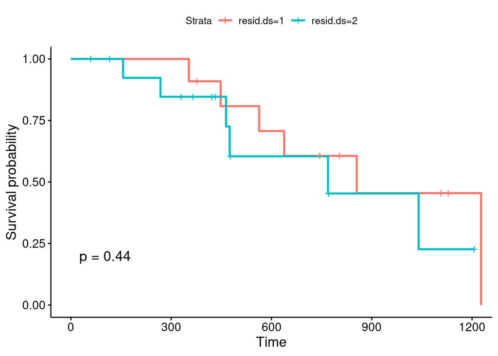

```r
ggsurvplot(mod_2, data = d, pval = TRUE)
```

```r
mod3 <- survfit(surv_object ~ age_group, data = ovarian)
summary(mod3)
```

```
## Call: survfit(formula = surv_object ~ age_group, data = ovarian)
##
##                 age_group=old
##  time n.risk n.event survival std.err lower 95% CI upper 95% CI
##    59     20       1    0.950  0.0487        0.859        1.000
##   115     19       1    0.900  0.0671        0.778        1.000
##   156     18       1    0.850  0.0798        0.707        1.000
##   268     17       1    0.800  0.0894        0.643        0.996
##   353     16       1    0.750  0.0968        0.582        0.966
##   365     15       1    0.700  0.1025        0.525        0.933
##   431     12       1    0.642  0.1093        0.460        0.896
##   464     10       1    0.577  0.1157        0.390        0.855
##   475      9       1    0.513  0.1193        0.326        0.809
##   563      7       1    0.440  0.1227        0.255        0.760
##   638      6       1    0.367  0.1222        0.191        0.705
##
##                 age_group=young
##         time       n.risk      n.event     survival      std.err lower 95% CI
##      329.000        6.000        1.000        0.833        0.152        0.583
## upper 95% CI
##        1.000
```

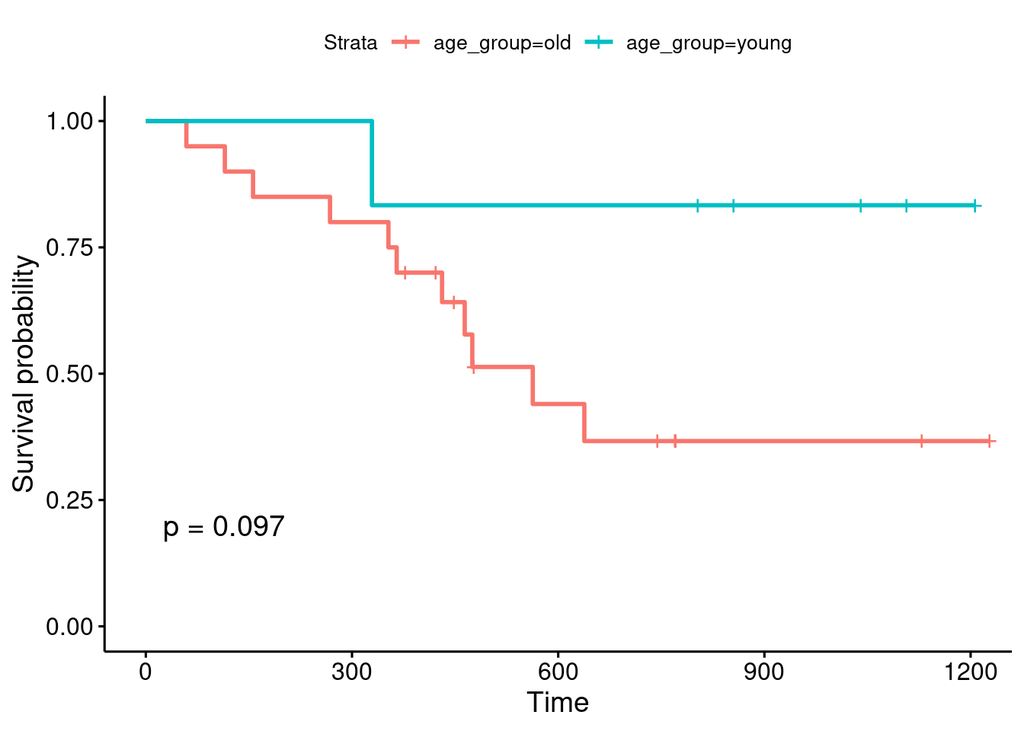

```r
ggsurvplot(mod3, data = ovarian, pval = TRUE)
```

```r
mod_3 <- survfit(surv_object_1 ~ age_group, data = d)
summary(mod_3)
```

```
## Call: survfit(formula = surv_object_1 ~ age_group, data = d)
##
##                 age_group=old
##  time n.risk n.event survival std.err lower 95% CI upper 95% CI
##   156     18       1    0.944  0.0540        0.844        1.000
##   268     17       1    0.889  0.0741        0.755        1.000
##   353     16       1    0.833  0.0878        0.678        1.000
##   448     11       1    0.758  0.1077        0.573        1.000
##   464     10       1    0.682  0.1207        0.482        0.964
##   475      9       1    0.606  0.1289        0.400        0.919
##   563      7       1    0.519  0.1365        0.310        0.869
##   638      6       1    0.433  0.1385        0.231        0.810
##   769      4       1    0.325  0.1399        0.140        0.756
##  1227      1       1    0.000     NaN           NA           NA
##
##                 age_group=young
##  time n.risk n.event survival std.err lower 95% CI upper 95% CI
##   855      4       1     0.75   0.217        0.426            1
##  1040      3       1     0.50   0.250        0.188            1
```

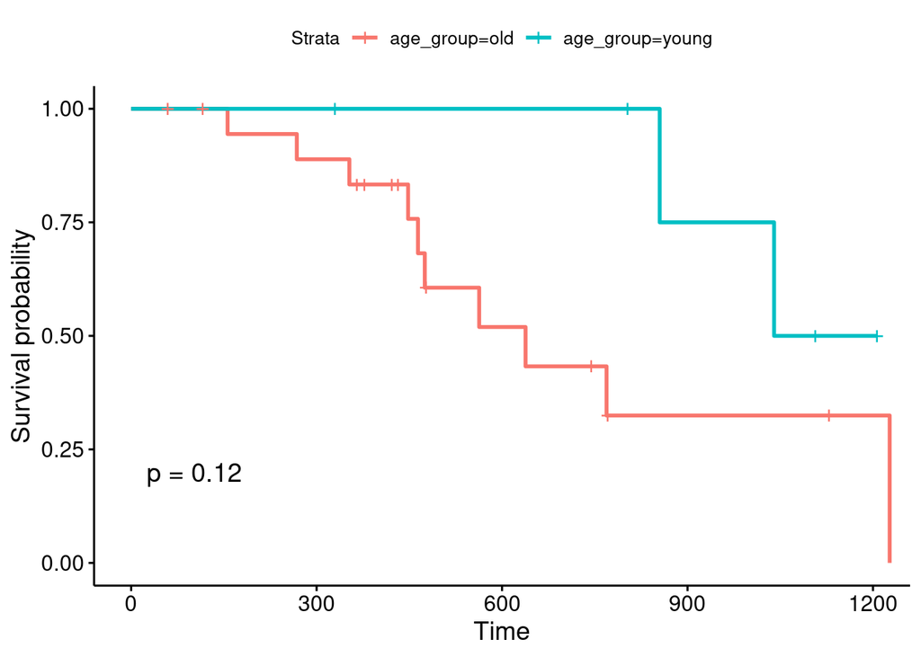

```r
ggsurvplot(mod_3, data = d, pval = TRUE)
```

Значение р = 0,1 говорит о том, что влияние возраста пациента на момент постановки диагноза также не влияет на исход заболевания. Значение р = 0,12 говорит о том, что параметр не имеет никакого влияния на статус пациента.

# 3. Лог-ранк тест

```r
logrank_test(Surv(ovarian$futime, ovarian$fustat) ~ rx, data = ovarian)
```

```
##
##  Asymptotic Two-Sample Logrank Test
##
## data:  Surv(ovarian$futime, ovarian$fustat) by rx (A, B)
## Z = -1.0296, p-value = 0.3032
## alternative hypothesis: true theta is not equal to 1
```

```r
logrank_test(Surv(ovarian$futime, ovarian$fustat) ~ resid.ds, data = ovarian)
```

```
##
##  Asymptotic Two-Sample Logrank Test
##
## data:  Surv(ovarian$futime, ovarian$fustat) by resid.ds (no, yes)
## Z = 1.9234, p-value = 0.05444
## alternative hypothesis: true theta is not equal to 1
```

```r
logrank_test(Surv(ovarian$futime, ovarian$fustat) ~ age_group, data = ovarian)
```

```
##
##  Asymptotic Two-Sample Logrank Test
##
## data:  Surv(ovarian$futime, ovarian$fustat) by age_group (old, young)
## Z = -1.7972, p-value = 0.07231
## alternative hypothesis: true theta is not equal to 1
```

Значения значимости при расчете лог-ранк теста практически не отличаются от тех (rx: 0,3 и 0,3032; resid.ds: 0,057 и 0,0544; age_group: 0,097 и 0,07231), что были рассчитаны при построении кривых К.-М., что позволяет повторить предыдущие выводы.

# 4. Анализ факторов, влияющих на риск (модель Кокса).

```r
cox <- coxph(formula = Surv(futime, fustat) ~ age_group + rx + resid.ds, data = ovarian)
summary(cox)
```

```
## Call:
## coxph(formula = Surv(futime, fustat) ~ age_group + rx + resid.ds,
##     data = ovarian)
##
##   n= 26, number of events= 12
##
##                   coef exp(coef) se(coef)      z Pr(>|z|)
## age_groupyoung -2.1146    0.1207   1.0910 -1.938   0.0526 .
## rxB            -1.2808    0.2778   0.6216 -2.060   0.0394 *
## resid.dsyes     1.2517    3.4962   0.6921  1.808   0.0705 .
## ---
## Signif. codes:  0 '***' 0.001 '**' 0.01 '*' 0.05 '.' 0.1 ' ' 1
##
##                exp(coef) exp(-coef) lower .95 upper .95
## age_groupyoung    0.1207      8.286   0.01422    1.0241
## rxB               0.2778      3.599   0.08215    0.9395
## resid.dsyes       3.4962      0.286   0.90044   13.5752
##
## Concordance= 0.771  (se = 0.067 )
## Likelihood ratio test= 11.31  on 3 df,   p=0.01
## Wald test            = 9.54  on 3 df,   p=0.02
## Score (logrank) test = 11.9  on 3 df,   p=0.008
```

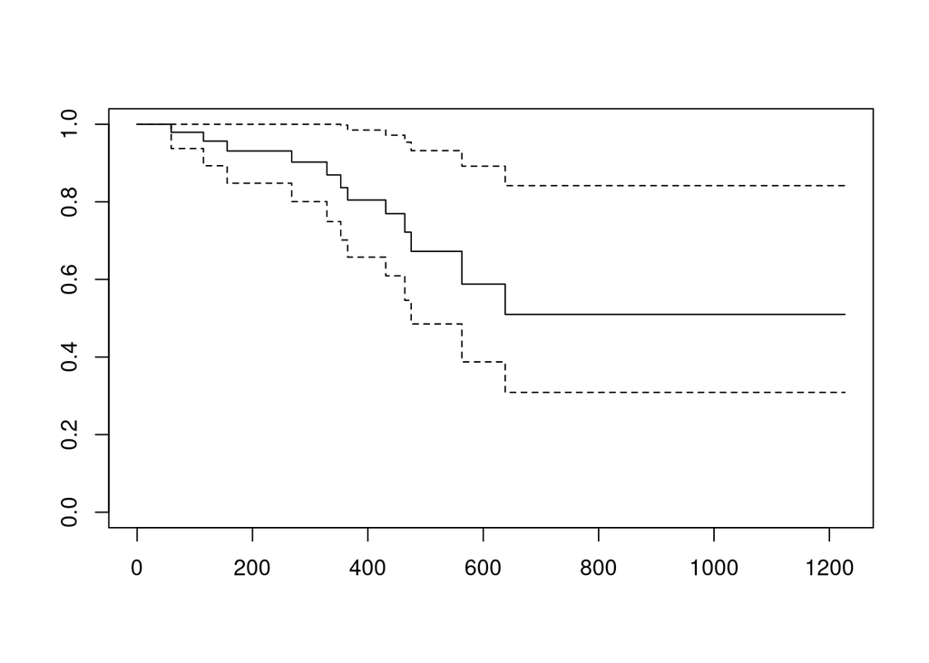

```r
cox_fit <- survfit(cox)
plot(cox_fit)
```

Данный анализ выделил только одну значимую группу - лекарство В.

#### Построим визуализацию влияния параметров.

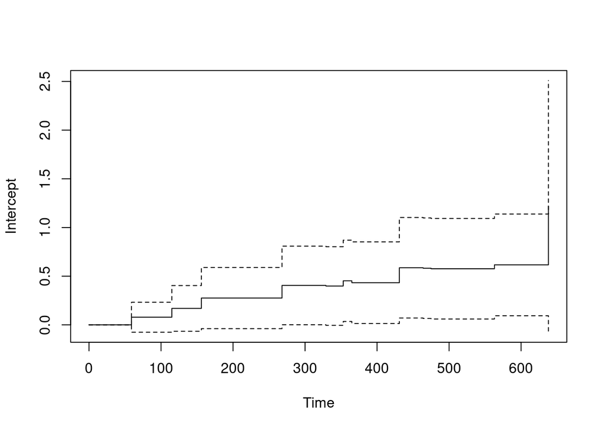

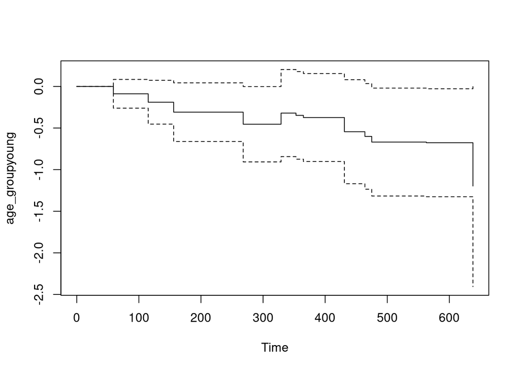

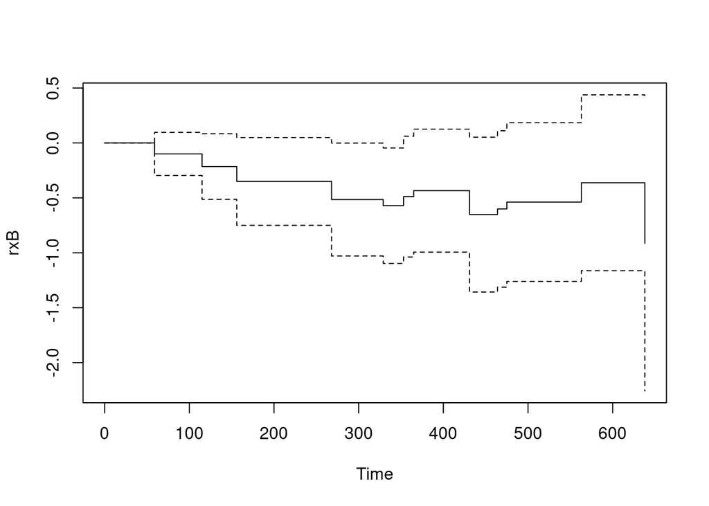

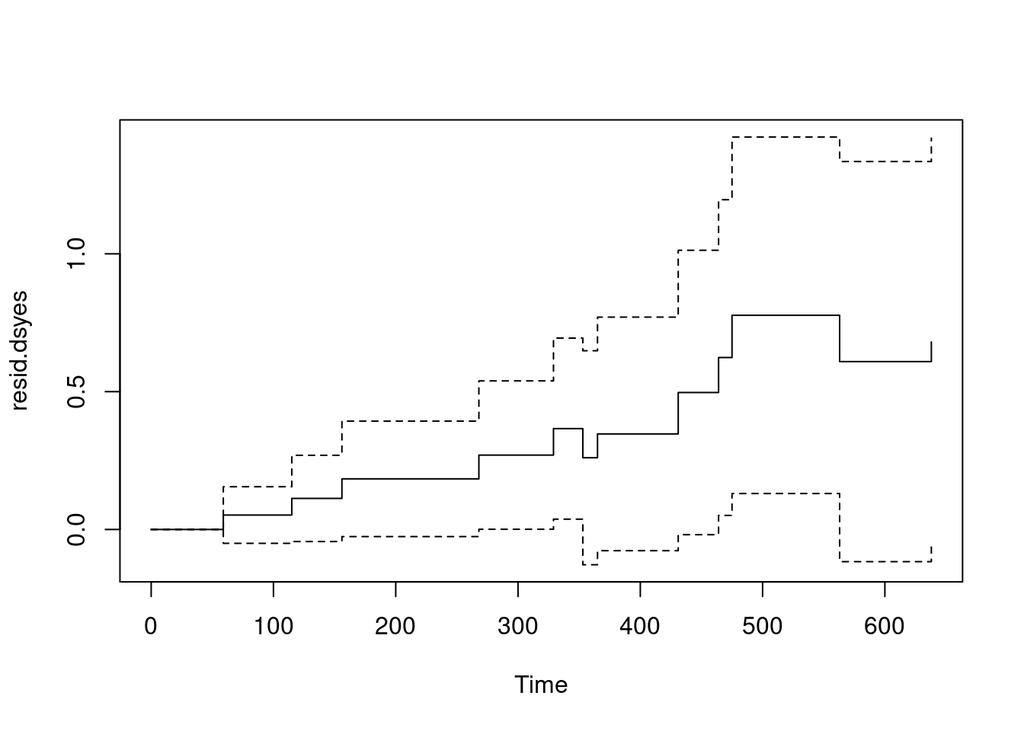

```r
aa_fit <- aareg(formula = Surv(futime, fustat) ~ age_group + rx + resid.ds, data = ovarian)
plot(aa_fit)
```